# The Grand Slam GOATs 🐐🐐

```r
# Load packages:

library(knitr)
library(tidyverse)
library(janitor)
```

```r
# Select of one female tennis player and one male tennis player:

female_player <- "Serena Williams"
# female_player <- "Martina Navratilova"
# female_player <- "Steffi Graf"
# female_player <- "Chris Evert"

male_player <- "Roger Federer"
# male_player <- "Novak Djokovic"
# male_player <- "Rafael Nadal"
# male_player <- "Jimmy Connors"



# Date of last data update:

update_date <- "March 2021"
```

# 1 Introduction

This press release was issued in February 2021, a few days after the Australian Open finals. It was quickly and widely reported by many media around the world. **Could we easily check if Roger and Serena have won 362 matches each in grand slam tournaments?**

[figure not shown]

```r
# Include a picture in the report:

include_graphics("roger_and_serena.jpg")
```

# 2 The Data

We can answer this question because we know where to find a very complete, detailed and reliable data source on tennis.

## 2.1 Credit where credit is due

The datasets we will be using are carefully assembled by [Jeff Sackmann](https://github.com/JeffSackmann) and is freely available on the internet in the form of github repositories. For reference, you can find the sources for the full women and men data respectively here:

- https://github.com/JeffSackmann/tennis_wta
- https://github.com/JeffSackmann/tennis_atp

For this first notebook, we have already done all the pre-processing so we can cut straight to the chase.

## 2.2 Import the data

The data can be found in the `data` folder. There is a file for the men (`atp_grand_slam_data.csv`) and one for the women (`wta_grand_slam_data.csv`).

```r
# Import atp and wta data:

# atp_grand_slam_data <- read_csv("../../data/tennis_data/atp_grand_slam_data.csv")
atp_grand_slam_data <- read_csv("https://raw.githubusercontent.com/gruggeri/tennis_atp/master/atp_grand_slam_data.csv")

# wta_grand_slam_data <- read_csv("../../data/tennis_data/wta_grand_slam_data.csv")
wta_grand_slam_data <- read_csv("https://raw.githubusercontent.com/gruggeri/tennis_wta/master/wta_grand_slam_data.csv")
```

## 2.3 Preliminary data exploration

```r
# Define the number of bottom and top rows to be displayed:

n_bottom <- 7
n_top <- 3
```

Here are the 7 bottom rows of `wta_grand_slam_data`:

```r
# Show bottom rows of atp_grand_slam_data:

slice_tail(wta_grand_slam_data, n = n_bottom)
```

| year | tourney_id | tourney_name | surface | tourney_level | tourney_date | match_num | winner_id | winner_name | winner_hand | winner_ht | winner_ioc | winner_age | loser_id | loser_name | loser_hand | loser_ht | loser_ioc | loser_age | score | best_of | round | minutes | w_ace | w_df | w_svpt | w_1st_in | w_1st_won | w_2nd_won | w_sv_gms | … |
| --- | --- | --- | --- | --- | --- | --- | --- | --- | --- | --- | --- | --- | --- | --- | --- | --- | --- | --- | --- | --- | --- | --- | --- | --- | --- | --- | --- | --- | --- | --- |
| 2021 | 2021-580 | Australian Open | Hard | G | 20210208 | 220 | 214096 | Karolina Muchova | R | NA | CZE | 24.46817 | 202458 | Ashleigh Barty | R | NA | AUS | 24.79398 | 1-6 6-3 6-2 | 3 | QF | NA | NA | NA | NA | NA | NA | NA | NA | … |
| 2021 | 2021-580 | Australian Open | Hard | G | 20210208 | 221 | 206108 | Jennifer Brady | R | NA | USA | 25.82888 | 202468 | Jessica Pegula | R | NA | USA | 26.95688 | 4-6 6-2 6-1 | 3 | QF | NA | NA | NA | NA | NA | NA | NA | NA | … |
| 2021 | 2021-580 | Australian Open | Hard | G | 20210208 | 222 | 211768 | Naomi Osaka | R | NA | JPN | 23.31554 | 201444 | Su Wei Hsieh | R | 169 | TPE | 35.09651 | 6-2 6-2 | 3 | QF | NA | NA | TRUE | NA | NA | NA | NA | NA | … |
| 2021 | 2021-580 | Australian Open | Hard | G | 20210208 | 223 | 200033 | Serena Williams | R | 175 | USA | 39.37029 | 201594 | Simona Halep | R | 168 | ROU | 29.36893 | 6-3 6-3 | 3 | QF | NA | NA | TRUE | NA | NA | NA | NA | NA | … |
| 2021 | 2021-580 | Australian Open | Hard | G | 20210208 | 224 | 206108 | Jennifer Brady | R | NA | USA | 25.82888 | 214096 | Karolina Muchova | R | NA | CZE | 24.46817 | 6-4 3-6 6-4 | 3 | SF | NA | NA | NA | NA | NA | NA | NA | NA | … |
| 2021 | 2021-580 | Australian Open | Hard | G | 20210208 | 225 | 211768 | Naomi Osaka | R | NA | JPN | 23.31554 | 200033 | Serena Williams | R | 175 | USA | 39.37029 | 6-3 6-4 | 3 | SF | NA | NA | NA | NA | NA | NA | NA | NA | … |
| 2021 | 2021-580 | Australian Open | Hard | G | 20210208 | 226 | 211768 | Naomi Osaka | R | NA | JPN | 23.31554 | 206108 | Jennifer Brady | R | NA | USA | 25.82888 | 6-4 6-3 | 3 | F | NA | NA | NA | NA | NA | NA | NA | NA | … |

And here are the 3 top rows of `wta_grand_slam_data`:

```r
# Show top rows of atp_grand_slam_data:

slice_head(wta_grand_slam_data, n = n_top)
```

| year | tourney_id | tourney_name | surface | tourney_level | tourney_date | match_num | winner_id | winner_name | winner_hand | winner_ht | winner_ioc | winner_age | loser_id | loser_name | loser_hand | loser_ht | loser_ioc | loser_age | score | best_of | round | minutes | w_ace | w_df | w_svpt | w_1st_in | w_1st_won | w_2nd_won | w_sv_gms | … |
| --- | --- | --- | --- | --- | --- | --- | --- | --- | --- | --- | --- | --- | --- | --- | --- | --- | --- | --- | --- | --- | --- | --- | --- | --- | --- | --- | --- | --- | --- | --- |
| 1968 | 1968-W-SL-AUS-01A-1968 | Australian Championships | Grass | G | 19680119 | 1 | 200130 | Dorothy Whitely | U | NA | AUS | NA | 200131 | Judith Gohn | U | NA | AUS | 22.69405 | 6-2 6-4 | 3 | R64 | NA | NA | NA | NA | NA | NA | NA | NA | … |
| 1968 | 1968-W-SL-AUS-01A-1968 | Australian Championships | Grass | G | 19680119 | 2 | 200133 | Eva De Jong | U | NA | NED | NA | 200132 | Kay Williams | U | NA | AUS | NA | 6-3 6-2 | 3 | R64 | NA | NA | NA | NA | NA | NA | NA | NA | … |
| 1968 | 1968-W-SL-AUS-01A-1968 | Australian Championships | Grass | G | 19680119 | 3 | 200134 | Kerry Ballard | U | NA | AUS | 18.09172 | 200135 | Lorraine Robinson | U | NA | AUS | 30.32170 | W/O | 3 | R64 | NA | NA | NA | NA | NA | NA | NA | NA | … |

# 3 Who are the top 20 players?

## 3.1 Female tennis players

The following table displays the 20 female tennis players with the highest number of Grand Slam wins from 1968 to March 2021.

```r
# Compute counts for female tennis players:

female_counts <- wta_grand_slam_data %>%
  count(winner_name, name = "n_won") %>%
  mutate(winner_name = fct_reorder(winner_name, n_won)) %>%
  slice_max(order_by = n_won, n = 20)

female_counts
```

| winner_name | n_won |
| --- | --- |
| Serena Williams | 362 |
| Martina Navratilova | 306 |
| Chris Evert | 299 |
| Steffi Graf | 280 |
| Venus Williams | 271 |
| Arantxa Sanchez Vicario | 212 |
| Lindsay Davenport | 198 |
| Maria Sharapova | 198 |
| Monica Seles | 181 |
| Conchita Martinez | 174 |

[output cut: 10 more lines]

We can better assess the above table using a barplot.

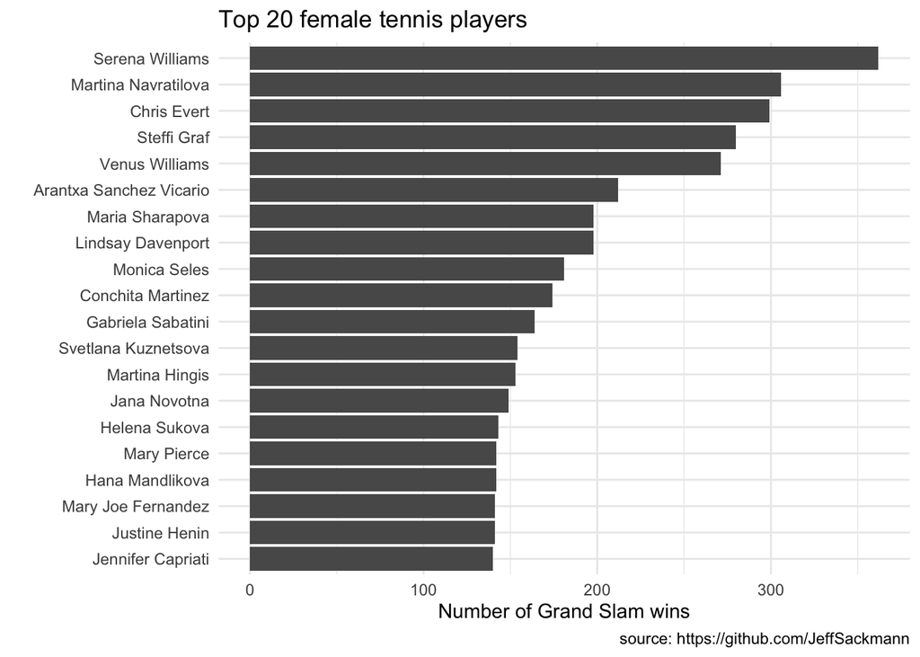

```r
# Draw barplot for female tennis players:

ggplot(data = female_counts,
       mapping = aes(x = n_won, y = winner_name)) +
  geom_col() +
  labs(title = "Top 20 female tennis players",
       x = "Number of Grand Slam wins",
       y = "",
       caption = "source: https://github.com/JeffSackmann")  +
  theme_minimal()
```

```r
# Compute the number of wins for female player:

female_n_wins <- wta_grand_slam_data %>%
  count(winner_name, name = "n_won") %>%
  filter(winner_name == female_player) %>%
  pull(n_won)
```

Based on tennis data from 1968 to March 2021, the total number of Grand Slam wins for Serena Williams is 362.

## 3.2 Male tennis players

```r
# Compute counts for male tennis players:

male_counts <- atp_grand_slam_data %>%
  count(winner_name, name = "n_won") %>%
  mutate(winner_name = fct_reorder(winner_name, n_won)) %>%
  slice_max(order_by = n_won, n = 20)

male_counts
```

| winner_name | n_won |
| --- | --- |
| Roger Federer | 366 |
| Novak Djokovic | 305 |
| Rafael Nadal | 287 |
| Jimmy Connors | 233 |
| Andre Agassi | 224 |
| Ivan Lendl | 222 |
| Pete Sampras | 203 |
| Andy Murray | 190 |
| Stefan Edberg | 178 |
| John McEnroe | 168 |

[output cut: 10 more lines]

We can better assess the above table using a barplot.

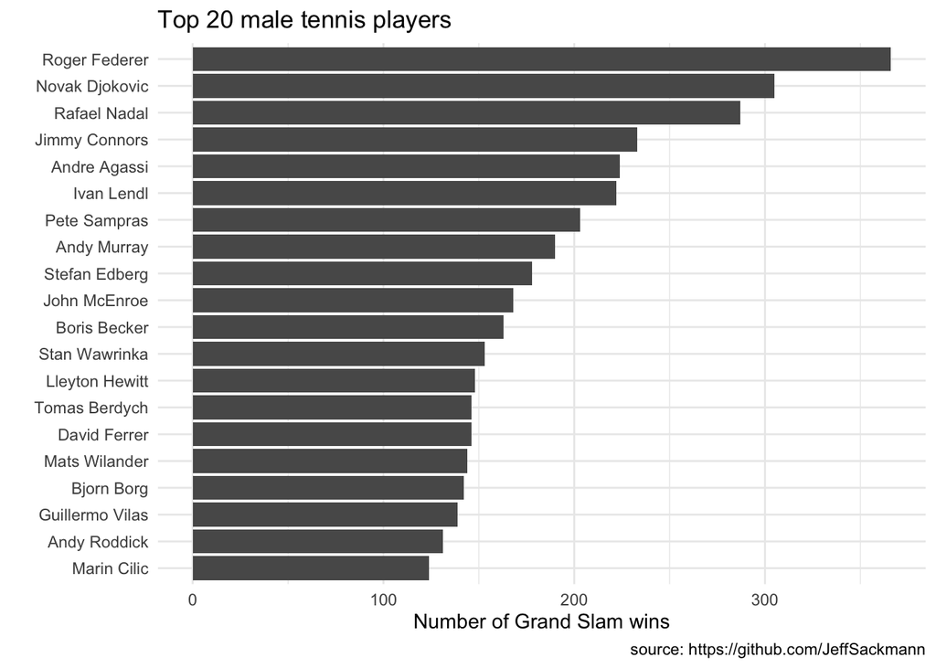

```r
# Draw barplot for male tennis players:

ggplot(data = male_counts,
       mapping = aes(x = n_won, y = winner_name)) +
  geom_col() +
  labs(title = "Top 20 male tennis players",
       x = "Number of Grand Slam wins",
       y = "",
       caption = "source: https://github.com/JeffSackmann")  +
  theme_minimal()
```

```r
# # Compute the number of wins for male player:

male_n_wins <- atp_grand_slam_data %>%
  count(winner_name, name = "n_won") %>%
  filter(winner_name == male_player) %>%
  pull(n_won)
```

Based on tennis data from 1968 to March 2021, the total number of Grand Slam wins for Roger Federer is 366.

# 4 Grand Slam wins per year and per tournament

## 4.1 Grand Slam wins for Serena Williams

The following table provides the number of Grand Slam wins per year (rows) and Grand Slam tournament (columns) from 1968 to March 2021. The last column gives the total number of Grand Slam wins per year, and the last row gives the total number of Grand Slam wins per tournament.

```r
# Compute counts per year for selected female player:

female_player_wins <- wta_grand_slam_data %>%
  filter(winner_name == female_player) %>%
  mutate(year = as.character(year)) %>%
  tabyl(year, tourney_name) %>%
  adorn_totals(c("row", "col"))

female_player_wins
```

|  | year | Australian Open | Roland Garros | US Open | Wimbledon | Total |
| --- | --- | --- | --- | --- | --- | --- |
| 1 | 1998 | 1 | 3 | 2 | 2 | 8 |
| 2 | 1999 | 2 | 2 | 7 | 0 | 11 |
| 3 | 2000 | 3 | 0 | 4 | 5 | 12 |
| 4 | 2001 | 4 | 4 | 6 | 4 | 18 |
| 5 | 2002 | 0 | 7 | 7 | 7 | 21 |
| 6 | 2003 | 7 | 5 | 0 | 7 | 19 |
| 7 | 2004 | 0 | 4 | 4 | 6 | 14 |
| 8 | 2005 | 7 | 0 | 3 | 2 | 12 |
| 9 | 2006 | 2 | 0 | 3 | 0 | 5 |
| 10 | 2007 | 7 | 4 | 4 | 4 | 19 |

[output cut: 15 more lines]

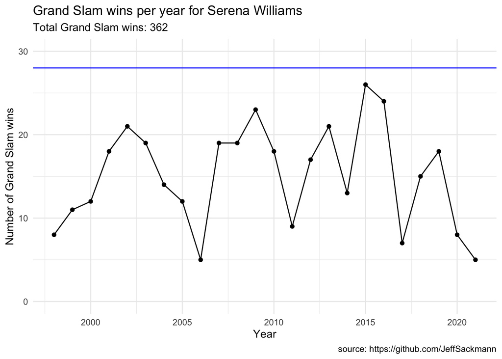

```r
# Draw lineplot for selected female player:

female_player_wins %>%
  filter(year != "Total") %>%
  ggplot(mapping = aes(x = as.numeric(year), y = Total)) +
  geom_hline(yintercept = 28, colour = "Blue") +
  geom_point() +
  geom_line() +
  ylim(0, 30) +
  labs(title = str_glue("Grand Slam wins per year for {female_player}"),
       subtitle = str_glue("Total Grand Slam wins: {female_n_wins}"),
       x = "Year",
       y = "Number of Grand Slam wins",
       caption = "source: https://github.com/JeffSackmann")  +
  theme_minimal()
```

## 4.2 Grand Slam wins for Roger Federer

The following table provides the number of Grand Slam wins per year (rows) and Grand Slam tournament (columns) from 1968 to March 2021. The last column gives the total number of Grand Slam wins per year, and the last row gives the total number of Grand Slam wins per tournament.

```r
# Compute counts per year for selected male player:

male_player_wins <- atp_grand_slam_data %>%
  filter(winner_name == male_player) %>%
  mutate(year = as.character(year)) %>%
  tabyl(year, tourney_name) %>%
  adorn_totals(c("row", "col"))

male_player_wins
```

|  | year | Australian Open | Roland Garros | US Open | Wimbledon | Total |
| --- | --- | --- | --- | --- | --- | --- |
| 1 | 2000 | 2 | 3 | 2 | 0 | 7 |
| 2 | 2001 | 2 | 4 | 3 | 4 | 13 |
| 3 | 2002 | 3 | 0 | 3 | 0 | 6 |
| 4 | 2003 | 3 | 0 | 3 | 7 | 13 |
| 5 | 2004 | 7 | 2 | 7 | 7 | 23 |
| 6 | 2005 | 5 | 5 | 7 | 7 | 24 |
| 7 | 2006 | 7 | 6 | 7 | 7 | 27 |
| 8 | 2007 | 7 | 6 | 7 | 7 | 27 |
| 9 | 2008 | 5 | 6 | 7 | 6 | 24 |
| 10 | 2009 | 6 | 7 | 6 | 7 | 26 |

[output cut: 12 more lines]

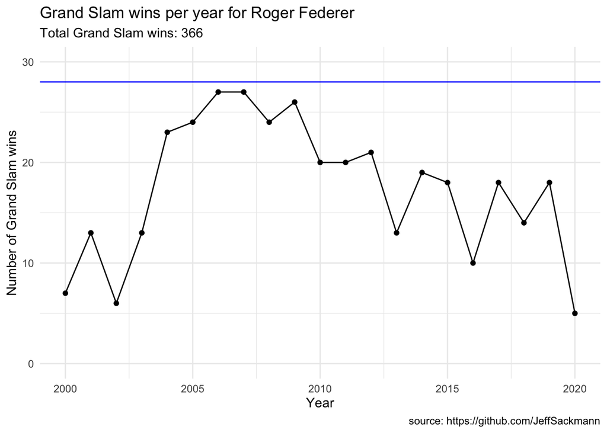

```r
# Draw lineplot for selected male player:

male_player_wins %>%
  filter(year != "Total") %>%
  ggplot(mapping = aes(x = as.numeric(year), y = Total)) +
  geom_hline(yintercept = 28, colour = "Blue") +
  geom_point() +
  geom_line() +
  ylim(0, 30) +
  labs(title = str_glue("Grand Slam wins per year for {male_player}"),
       subtitle = str_glue("Total Grand Slam wins: {male_n_wins}"),
       x = "Year",
       y = "Number of Grand Slam wins",
       caption = "source: https://github.com/JeffSackmann")  +
  theme_minimal()
```